# Importing Libraries and functions

```python
import pandas as pd
import numpy as np
import seaborn as sns
import matplotlib.pyplot as plt
from sklearn.model_selection import train_test_split, GridSearchCV
from sklearn.preprocessing import StandardScaler, OneHotEncoder
from sklearn.compose import ColumnTransformer
from sklearn.linear_model import LinearRegression
from sklearn.ensemble import RandomForestRegressor
from sklearn.svm import SVR
from sklearn.metrics import mean_absolute_error, mean_squared_error, r2_score
```

```python
def println(*args):
  for arg in args:
    print(arg, "\n")
```

# Data Collection

I collected data regarding health insurance cost which can be found data set at https://www.kaggle.com/code/priyang/health-insurance-cost-prediction-using-ml?scriptVersionId=78467794&select=insurance.csv

I will predict medical insurance charges as the main target based on a person's demographic and health-related features to help insurance companies set fair pricing policies.

```python
df_org = pd.read_csv("insurance.csv")
```

```python
df_org.head()
```

|  | age | sex | bmi | children | smoker | region | charges |
| --- | --- | --- | --- | --- | --- | --- | --- |
| 0 | 19 | female | 27.900 | 0 | yes | southwest | 16884.92400 |
| 1 | 18 | male | 33.770 | 1 | no | southeast | 1725.55230 |
| 2 | 28 | male | 33.000 | 3 | no | southeast | 4449.46200 |
| 3 | 33 | male | 22.705 | 0 | no | northwest | 21984.47061 |
| 4 | 32 | male | 28.880 | 0 | no | northwest | 3866.85520 |

# Data Exploration

I check for missing values, data types, and statistical summary.

```python
println(df_org.info(), df_org.isnull().sum(), df_org.describe(), df_org.shape)
```

```
<class 'pandas.core.frame.DataFrame'>
RangeIndex: 1338 entries, 0 to 1337
Data columns (total 7 columns):
 #   Column    Non-Null Count  Dtype
---  ------    --------------  -----
 0   age       1338 non-null   int64
 1   sex       1338 non-null   object
 2   bmi       1338 non-null   float64
 3   children  1338 non-null   int64
 4   smoker    1338 non-null   object
 5   region    1338 non-null   object
 6   charges   1338 non-null   float64
dtypes: float64(2), int64(2), object(3)
memory usage: 73.3+ KB
None

age         0
sex         0
bmi         0
children    0
smoker      0
region      0
charges     0
dtype: int64

               age          bmi     children       charges
count  1338.000000  1338.000000  1338.000000   1338.000000
mean     39.207025    30.663397     1.094918  13270.422265
std      14.049960     6.098187     1.205493  12110.011237
min      18.000000    15.960000     0.000000   1121.873900
25%      27.000000    26.296250     0.000000   4740.287150
50%      39.000000    30.400000     1.000000   9382.033000
75%      51.000000    34.693750     2.000000  16639.912515
max      64.000000    53.130000     5.000000  63770.428010

(1338, 7)
```

```python
println(df_org['sex'].unique(), df_org['smoker'].unique(), df_org['region'].unique())
```

```
['female' 'male']

['yes' 'no']

['southwest' 'southeast' 'northwest' 'northeast']
```

1. (Age - Charges) Older and smoker people generally have higher insurance costs.
2. (BMI - Charges) Smokers with high BMI have significantly higher charges.
3. (Children - Charges) The number of children a person have does not impact insurance charges meaning no correlation.

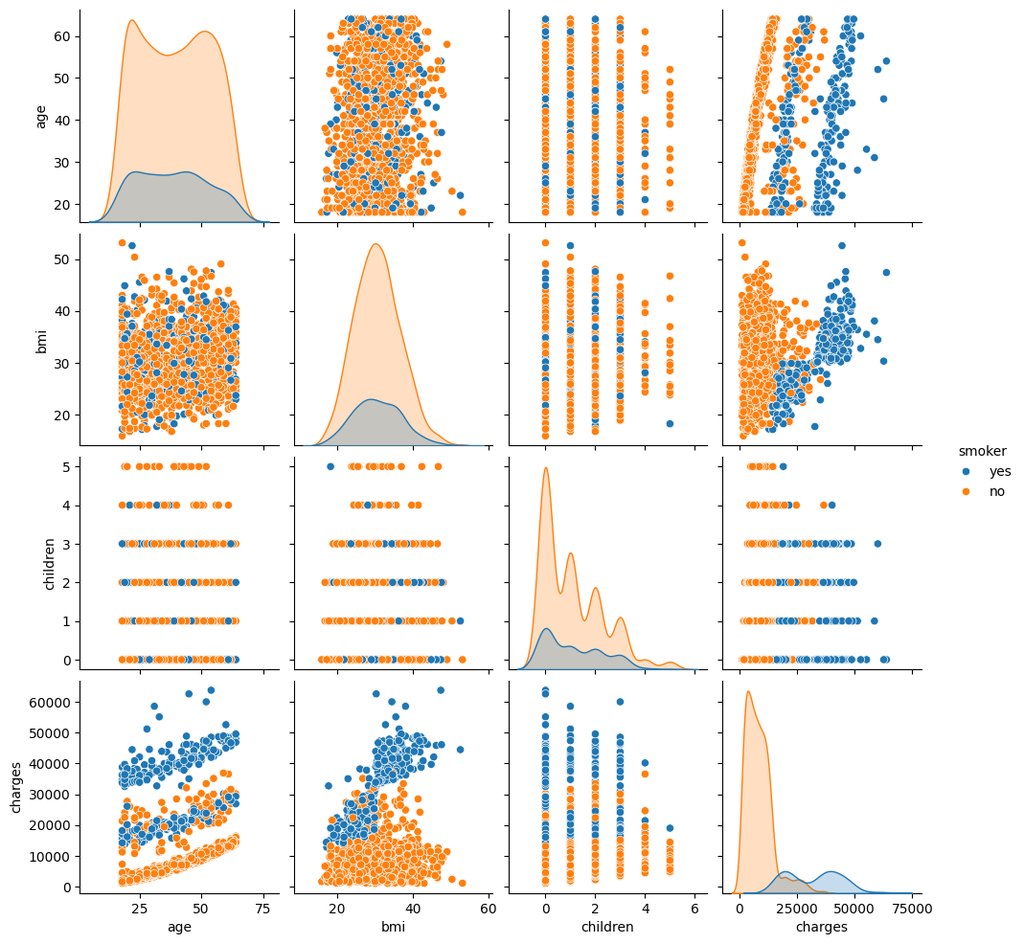

```python
sns.pairplot(df_org, hue="smoker")
plt.show()
```

# Data Preprocessing

All features are stored in X to determine insurance cost which is the target variable and stored in y.

```python
X = df_org.drop(['charges'], axis=1)
y = df_org['charges']
print(df_org.shape, X.shape, y.shape)
```

```
(1338, 7) (1338, 6) (1338,)
```

```python
X_train, X_test, y_train, y_test = train_test_split(X, y, test_size=0.2, random_state=42)
```

# Feature Engineering

I split features into categorical and numerical by converting categorical features into numbers and normalizing numerical features to help models perform better.

```python
categorical_features = X_train.select_dtypes(include=["object"]).columns
numerical_features   = X_train.select_dtypes(include=["int64", "float64"]).columns

preprocessor = ColumnTransformer(
    transformers=[
        ("num", StandardScaler(), numerical_features),
        ("cat", OneHotEncoder(drop="first", handle_unknown='ignore'), categorical_features)
    ]
)
println(categorical_features, numerical_features)
```

```
Index(['sex', 'smoker', 'region'], dtype='object')

Index(['age', 'bmi', 'children'], dtype='object')
```

Training Data is computed and learned based on the mean and standard deviation of each feature.

Test Dataset is Prevented Data Leakage and so I only apply transformation.

```python
X_train_transformed = preprocessor.fit_transform(X_train)
X_test_transformed = preprocessor.transform(X_test)
```

```python
print("x_train size", X_train.shape)
print("x_train_transformed size", X_train_transformed.shape)

print("x_test size", X_test.shape)
print("x_test_transformed size", X_test_transformed.shape)
```

```
x_train size (1070, 6)
x_train_transformed size (1070, 8)
x_test size (268, 6)
x_test_transformed size (268, 8)
```

# Train the models: fit()

I will try some models to figure out which model will perform best.

```python
lr = LinearRegression()
lr.fit(X_train_transformed, y_train)
svm = SVR()
svm.fit(X_train_transformed, y_train)
rf = RandomForestRegressor()
rf.fit(X_train_transformed, y_train)
```

```
RandomForestRegressor()
```

I make some predictions using the trained models and comparing them to the actual value.

```python
y_pred_lr = lr.predict(X_test_transformed)
y_pred_svm = svm.predict(X_test_transformed)
y_pred_rf = rf.predict(X_test_transformed)

df1 = pd.DataFrame({'Actual':y_test,'Lr':y_pred_lr, 'svm':y_pred_svm,'rf':y_pred_rf})
```

```python
df1
```

|  | Actual | Lr | svm | rf |
| --- | --- | --- | --- | --- |
| 764 | 9095.06825 | 8969.550274 | 9550.525315 | 9668.544262 |
| 887 | 5272.17580 | 7068.747443 | 9510.834636 | 5247.416900 |
| 890 | 29330.98315 | 36858.410912 | 9627.573789 | 28422.974008 |
| 1293 | 9301.89355 | 9454.678501 | 9561.321562 | 12174.230079 |
| 259 | 33750.29180 | 26973.173457 | 9522.233117 | 34808.187798 |
| ... | ... | ... | ... | ... |
| 109 | 47055.53210 | 39061.500932 | 9632.745029 | 47437.265700 |
| 575 | 12222.89830 | 11761.499198 | 9613.304789 | 12139.232939 |
| 535 | 6067.12675 | 7687.563632 | 9508.995476 | 5959.103070 |
| 543 | 63770.42801 | 40920.291512 | 9587.450063 | 46707.510714 |
| 846 | 9872.70100 | 12318.586653 | 9591.771269 | 10078.570591 |

268 rows × 4 columns

I will evaluate prediction of each model accuracy using key metrics. This analysis will help to choose the best model for insurance pricing strategies.

Random Forest (RF) is the best model based on below metrics -

- the highest R² score, indicating the best fit to the datat
- the lowest MAE, indicating the smallest errors
- the lowest RMSE, indicating better model performance

```python
r2_score1 = r2_score(y_test,y_pred_lr)
r2_score2 = r2_score(y_test,y_pred_svm)
r2_score3 = r2_score(y_test,y_pred_rf)
print(r2_score1, r2_score2, r2_score3)
```

```
0.7835929767120723 -0.07149402790922443 0.8643631294732992
```

```python
mae_score1 = mean_absolute_error(y_test,y_pred_lr)
mae_score2 = mean_absolute_error(y_test,y_pred_svm)
mae_score3 = mean_absolute_error(y_test,y_pred_rf)
print(mae_score1, mae_score2, mae_score3)
```

```
4181.194473753649 8606.59226132562 2513.0436644171186
```

```python
rmse_score1 = np.sqrt(mean_squared_error(y_test, y_pred_lr))
rmse_score2 = np.sqrt(mean_squared_error(y_test, y_pred_svm))
rmse_score3 = np.sqrt(mean_squared_error(y_test, y_pred_rf))
print(rmse_score1, rmse_score2, rmse_score3)
```

```
5796.2846592762735 12897.6001114129 4588.839950661193
```

# Random Forest (RF)

I deal with Hyperparameter Tuning to improve model accuracy by finding the best settings for RF.

```python
# Define parameter grid for Random Forest
param_grid = {
    'n_estimators': [50, 100, 200],
    'max_depth': [None, 10, 20],
    'min_samples_split': [2, 5, 10],
    'min_samples_leaf': [1, 2, 4]
}

rf_model = RandomForestRegressor(random_state=42)

# Grid search with cross-validation (5-fold CV)
grid_search = GridSearchCV(estimator=rf_model, param_grid=param_grid, n_jobs=-1)

# Train the model with different hyperparameters
grid_search.fit(X_train_transformed, y_train)

# Get the best model with optimal parameters
best_rf = grid_search.best_estimator_
print("Best hyperparameters:", grid_search.best_params_)
```

```
Best hyperparameters: {'max_depth': 10, 'min_samples_leaf': 4, 'min_samples_split': 10, 'n_estimators': 200}
```

I evaluate the performance on Unseen Test Data before & after condition of tuning hyperparameter, which can be seen the best model with highest R2, lowest MAE, lowest RMSE

```python
# Predict on test data using the best model
y_pred_best_rf = best_rf.predict(X_test_transformed)

# Calculate performance metrics
r2 = r2_score(y_test, y_pred_best_rf)
mae = mean_absolute_error(y_test, y_pred_best_rf)
rmse = np.sqrt(mean_squared_error(y_test, y_pred_best_rf))

print("Random Forest Before tuning hyperparameter:")
print(f"R² Score: {r2_score3:.4f}, MAE: {mae_score3:.2f}, RMSE: {rmse_score3:.2f}")

print("\nRandom Forest After tuning hyperparameter:")
print(f"R² Score: {r2:.4f}, MAE: {mae:.2f}, RMSE: {rmse:.2f}")
```

```
Random Forest Before tuning hyperparameter:
R² Score: 0.8644, MAE: 2513.04, RMSE: 4588.84

Random Forest After tuning hyperparameter:
R² Score: 0.8775, MAE: 2478.83, RMSE: 4360.15
```

- The business might modify premiums in accordance with the fact that smoking and having a high body mass index (BMI) considerably raise costs.
- Adding more features such as medical history, lifestyle, social activities, job, streess could improve prediction accuracy.